# Semibalanus shading experiment

Amelia Hesketh

06/10/2021

# Objectives

This experiment is designed to document how communities differ (in terms of Shannon diversity, species richness, and total abundance of organisms) between Semibalanus beds that are shaded vs. unshaded during the summer season. Shades reduce temperature (and desiccation stress). I also scraped a subset of plots to see how early succession is affected by the presence or absence of shades.

I want to examine: 1) How communities differ in mulitdimensional space between treatments - what is their dispersion, and how far apart are they? 2) How Shannon diversity differs 3) How richness differs 4) How total abundance differs

# Temperature data

```r
library(tidyverse)
library(lubridate)
library(car)
library(vegan)

temp.files <- list.files("../raw_data/ibutton_temp/")

temp.df.all.aug <- data.frame(matrix(ncol = 4))
colnames(temp.df.all.aug) <- c("Date/Time", "Unit", "Value", "file_name")

for (file in 1: length(temp.files)){
  file.name = paste("../raw_data/ibutton_temp/", temp.files[file], sep = "")
  temp.df <- read_csv(file.name, skip = 14) %>% mutate(file_name = temp.files[file])
  if (str_detect(file.name, "07")==TRUE){
    if (file == 1){
    temp.df.all.july <- temp.df
  }
  if (file > 1){
    temp.df.all.july <- rbind(temp.df.all.july, temp.df)
  }
  }
  else {
    temp.df.all.aug <- rbind(temp.df.all.aug, temp.df)
  }
}

temp.df.clean.july <- temp.df.all.july %>% mutate(Value = str_remove_all(Value, "C,")) %>% separate(file_name, sep = "_", into = c("block","treatment","extra")) %>% select(-extra) %>% rename(date = 1, time = 2, temperature_C = 3) %>%
mutate(time = toupper(str_remove_all(time, fixed(".")))) %>% mutate(time = parse_time(time, "%I:%M:%S %p")) %>% unite(date_time, c(date, time), sep = " ") %>% mutate(date_time = as_datetime(date_time), temperature_C = as.numeric(temperature_C))

temp.df.clean.aug <- temp.df.all.aug %>% na.omit() %>% select(-Unit) %>% separate(file_name, sep = "_", into = c("block","treatment","extra")) %>% select(-extra) %>% rename(date_time = 1, temperature_C = 2) %>% mutate(date_time = parse_date_time(date_time, "%d/%m/%y %I:%M:%S %p"))

temp.clean <- temp.df.clean.aug %>%  full_join(temp.df.clean.july) %>% mutate(treatment = case_when(treatment == 1 ~ "UI", treatment == 2 ~ "SI", treatment == 3 ~ "UR", treatment == 4 ~ "SR")) %>% filter(date_time < "2021-08-21 6:00:00" & date_time > "2021-04-17 15:00:00")
```

```r
temp.sep <- temp.clean %>% separate(date_time, into = c("date","time"), sep = " ")
temp.summary <- temp.sep %>% group_by(date, treatment) %>% summarize(mean_temp = mean(temperature_C)) %>% mutate(date = date(date))
```

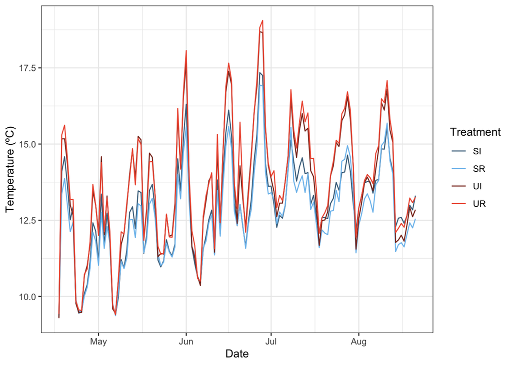

```r
ggplot(data = temp.summary, aes(x = date, y = mean_temp, col = treatment)) + geom_line() + scale_color_manual(values = c("skyblue4","skyblue2", "tomato4", "tomato2")) + labs(x = "Date", y = "Temperature (ºC)", color = "Treatment") + theme(axis.title = element_text(size = 14), axis.text = element_text(size = 12), legend.text = element_text(size = 12), legend.title = element_text(size = 14)) + theme_bw()
```

The temperature is highest in the unshaded treatments (as expected) by (at times) a substantial margin. What does this break down to in a boxplot sense?

```r
temp.summary2 <- temp.sep %>% group_by(treatment, date) %>% summarize(mdmax_temp = max(temperature_C))
```

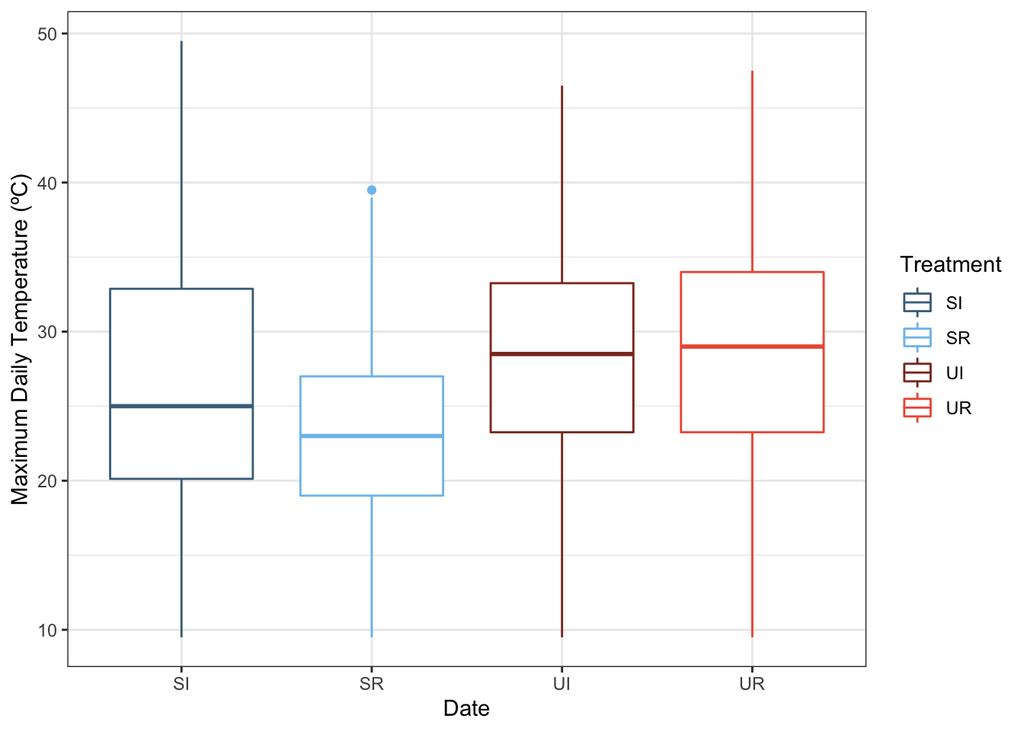

```r
ggplot(data = temp.summary2 %>% filter(mdmax_temp < 50), aes(x = treatment, y = mdmax_temp, col = treatment)) + geom_boxplot() + scale_color_manual(values = c("skyblue4","skyblue2", "tomato4", "tomato2")) + labs(x = "Date", y = "Maximum Daily Temperature (ºC)", color = "Treatment") +  theme(axis.title = element_text(size = 14), axis.text = element_text(size = 12), legend.text = element_text(size = 12), legend.title = element_text(size = 14)) + theme_bw()
```

There’s something odd going on here with one of the SI plots. Need to look into it a bit more.

```r
temp.model <- lm(mdmax_temp ~ treatment, data = temp.summary2 %>% filter(mdmax_temp < 50))
summary(temp.model)
```

```
##
## Call:
## lm(formula = mdmax_temp ~ treatment, data = temp.summary2 %>%
##     filter(mdmax_temp < 50))
##
## Residuals:
##      Min       1Q   Median       3Q      Max
## -18.7756  -4.9996  -0.1693   5.7244  23.0992
##
## Coefficients:
##             Estimate Std. Error t value Pr(>|t|)
## (Intercept)  26.4008     0.6702  39.394  < 2e-16 ***
## treatmentSR  -3.2315     0.9459  -3.416 0.000686 ***
## treatmentUI   1.1976     0.9459   1.266 0.206052
## treatmentUR   1.8748     0.9459   1.982 0.048020 *
## ---
## Signif. codes:  0 '***' 0.001 '**' 0.01 '*' 0.05 '.' 0.1 ' ' 1
##
## Residual standard error: 7.523 on 503 degrees of freedom
## Multiple R-squared:  0.06423,    Adjusted R-squared:  0.05865
## F-statistic: 11.51 on 3 and 503 DF,  p-value: 2.617e-07
```

```r
anova(temp.model)
```

```
## Analysis of Variance Table
##
## Response: mdmax_temp
##            Df Sum Sq Mean Sq F value    Pr(>F)
## treatment   3   1954  651.32  11.509 2.617e-07 ***
## Residuals 503  28465   56.59
## ---
## Signif. codes:  0 '***' 0.001 '**' 0.01 '*' 0.05 '.' 0.1 ' ' 1
```

# Infaunal community

```r
library(vegan)

collection.info <- read_csv("../raw_data/shade/SBC_SHADE_plot_info.csv")
survey.info <- read_csv("../raw_data/shade/SBC_SHADE_survey_info.csv")

infauna.shade <- read_csv("../raw_data/shade/SBC_SHADE_infauna.csv") %>% rename(plot_number = plot_id) %>% left_join(collection.info) %>% rename(treatment = treatment_original_numeric) %>% mutate(treatment = case_when(treatment == 1 ~ "UI", treatment == 2 ~ "SI", treatment == 3 ~ "UR", treatment == 4 ~ "SR")) %>% select(-shore_level, -treatment_final_numeric)

#get rid of everything and convert to matrix
infauna.matrix <- infauna.shade %>%
  select(-plot_number, -block, -treatment)

# convert to matrix
infauna.matrix <- as.matrix(infauna.matrix)

# ready to analyze
comm.infauna <- metaMDS(infauna.matrix, k = 2, try = 400)

# can't get ordplot to display in .Rmd file

factors.infauna <-infauna.shade %>% select(treatment, block)

perm.y1 <- adonis(infauna.matrix ~ treatment, data = factors.infauna,
                  perm = 99)

dist.y1 <- vegdist(infauna.matrix, method = "bray")
disp.y1 <- betadisper(dist.y1, type = "centroid", group = factors.infauna$treatment)
```

```r
perm.y1
```

```
##
## Call:
## adonis(formula = infauna.matrix ~ treatment, data = factors.infauna,      permutations = 99)
##
## Permutation: free
## Number of permutations: 99
##
## Terms added sequentially (first to last)
##
##           Df SumsOfSqs MeanSqs F.Model     R2 Pr(>F)
## treatment  1   0.34883 0.34883  3.6436 0.1765   0.01 **
## Residuals 17   1.62753 0.09574         0.8235
## Total     18   1.97636                 1.0000
## ---
## Signif. codes:  0 '***' 0.001 '**' 0.01 '*' 0.05 '.' 0.1 ' ' 1
```

```r
anova(disp.y1)
```

```
## Analysis of Variance Table
##
## Response: Distances
##           Df   Sum Sq   Mean Sq F value  Pr(>F)
## Groups     1 0.018042 0.0180422  3.4504 0.08065 .
## Residuals 17 0.088894 0.0052291
## ---
## Signif. codes:  0 '***' 0.001 '**' 0.01 '*' 0.05 '.' 0.1 ' ' 1
```

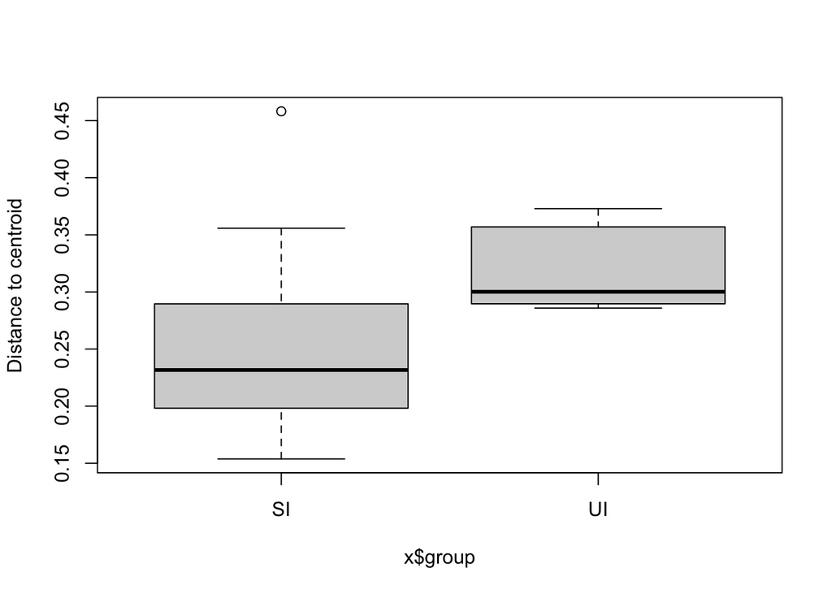

[figure not shown]

```r
boxplot(disp.y1)
```

# Mortality in shaded vs. unshaded

```r
barnacle.mort <- read_csv("../raw_data/shade/SBC_SHADE_semibalanusmort.csv") %>% mutate(prop_mort = (number_dead)/(number_live+number_dead)) %>% filter(prop_mort != "NaN")

plot.info <- read_csv("../raw_data/shade/SBC_SHADE_plot_info.csv")

mort.complete <- barnacle.mort %>% left_join(plot.info) %>% filter((plot_number %in% c(15,35,36,40)) == F) %>% select(prop_mort, treatment_original_numeric, plot_number) %>% rename(treatment = treatment_original_numeric) %>% mutate(treatment = case_when(treatment == 1 ~ "UI", treatment == 2 ~ "SI", treatment == 3 ~ "UR", treatment == 4 ~ "SR"))

mort.beds <- mort.complete %>% filter(treatment %in% c("SI","UI"))

shade.mort.model <- lm(prop_mort ~ treatment, data = mort.beds)
```

```r
summary(shade.mort.model)
```

```
##
## Call:
## lm(formula = prop_mort ~ treatment, data = mort.beds)
##
## Residuals:
##      Min       1Q   Median       3Q      Max
## -0.62554 -0.03232  0.00003  0.19683  0.37446
##
## Coefficients:
##             Estimate Std. Error t value Pr(>|t|)
## (Intercept)  0.03232    0.09040   0.358    0.724
## treatmentUI  0.59322    0.12240   4.846 9.79e-05 ***
## ---
## Signif. codes:  0 '***' 0.001 '**' 0.01 '*' 0.05 '.' 0.1 ' ' 1
##
## Residual standard error: 0.2859 on 20 degrees of freedom
## Multiple R-squared:  0.5401, Adjusted R-squared:  0.5171
## F-statistic: 23.49 on 1 and 20 DF,  p-value: 9.791e-05
```

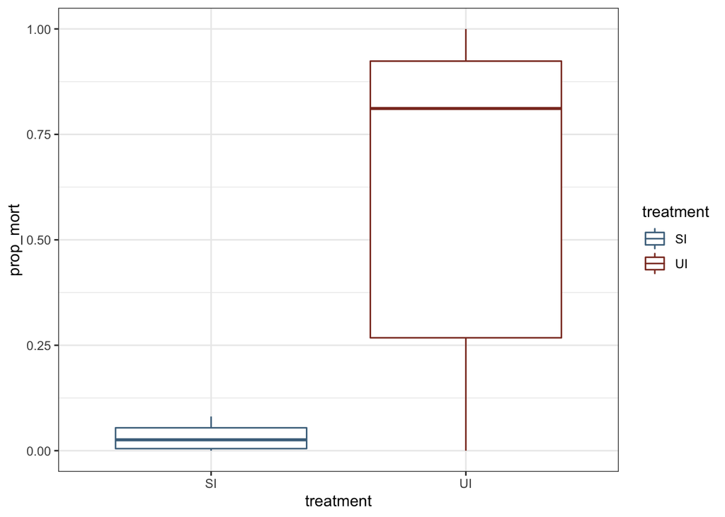

```r
ggplot(mort.beds, aes(x = treatment, y = prop_mort, col = treatment)) + geom_boxplot() +  theme(axis.title = element_text(size = 14), axis.text = element_text(size = 12), legend.text = element_text(size = 12), legend.title = element_text(size = 14)) + theme_bw() + scale_color_manual( values = c("skyblue4", "tomato4"))
```

Clearly, having a shade positively affected barnacle survival. What about species richness/diversity based on visual surveys??

```r
visuals <- read_csv("../raw_data/shade/SBC_SHADE_visual_3_202108.csv")

# separate the cover and count data

taxa <- read_csv("../raw_data/shade/SBC_SHADE_taxonomic_20211004.csv") %>% select(taxon_code, kingdom)

algae <- taxa %>% filter(kingdom != "Animalia") %>% select(-kingdom)
animal <- taxa %>% filter(kingdom == "Animalia") %>% select(-kingdom)

# algal diversity & abund

visuals.long <- visuals %>% pivot_longer(cols = c(2:length(visuals)), names_to = "taxon_code", values_to = "abund")

visuals.algae <- visuals.long %>% right_join(algae) %>% pivot_wider(names_from = "taxon_code", values_from = "abund") %>% select(-ULSP) %>% na.omit()

H <- diversity(visuals.algae)
total_cover <- rowSums(visuals.algae %>% select(-plot_number))

diversity.algae <- cbind(visuals.algae$plot_number, H, total_cover)
colnames(diversity.algae) <- c("plot_number","H", "total_cover")
diversity.algae <- as.data.frame(diversity.algae)

diversity.algae.trts <- diversity.algae %>% full_join(plot.info) %>% select(-plot_number, -treatment_final_numeric, -shore_level) %>% rename(treatment = treatment_original_numeric) %>% mutate(treatment = case_when(treatment == 1 ~ "UI", treatment == 2 ~ "SI", treatment == 3 ~ "UR", treatment == 4 ~ "SR"))

# animal diversity & abund

visuals.animals <- visuals.long %>% right_join(animal) %>% pivot_wider(names_from = "taxon_code", values_from = "abund") %>% select(-c(GNOR:NEVE)) %>% na.omit()

H <- diversity(visuals.animals)
abund <- rowSums(visuals.animals %>% select(-plot_number))

diversity.animals <- cbind(visuals.animals$plot_number, H, abund)
colnames(diversity.animals) <- c("plot_number","H", "abund")
diversity.animals <- as.data.frame(diversity.animals)

diversity.animals.trts <- diversity.animals %>% full_join(plot.info) %>% select(-plot_number, -treatment_final_numeric, -shore_level) %>% rename(treatment = treatment_original_numeric) %>% mutate(treatment = case_when(treatment == 1 ~ "UI", treatment == 2 ~ "SI", treatment == 3 ~ "UR", treatment == 4 ~ "SR"))

richness.all.taxa <- cbind(visuals$plot_number, specnumber(visuals))
colnames(richness.all.taxa) <- c("plot_number", "richness")
richness.all.taxa <- as.data.frame(richness.all.taxa)

richness.all.trts <- richness.all.taxa %>% full_join(plot.info) %>% select(-plot_number, -treatment_final_numeric, -shore_level) %>% rename(treatment = treatment_original_numeric) %>% mutate(treatment = case_when(treatment == 1 ~ "UI", treatment == 2 ~ "SI", treatment == 3 ~ "UR", treatment == 4 ~ "SR"))
```

# Plots of diversity & abundance

## 1: Species richness, all taxa

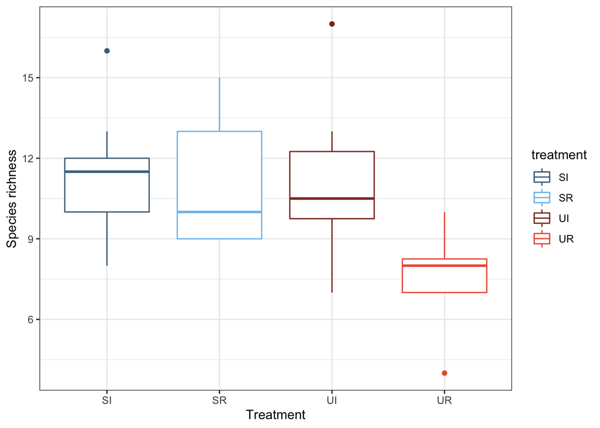

```r
ggplot(richness.all.trts, aes(x=treatment, y = richness, color = treatment)) + geom_boxplot() + labs(y = "Species richness", x = "Treatment") + scale_color_manual(values = c("skyblue4","skyblue2", "tomato4", "tomato2")) +  theme(axis.title = element_text(size = 14), axis.text = element_text(size = 12), legend.text = element_text(size = 12), legend.title = element_text(size = 14)) + theme_bw()
```

## 2: Animals only: Shannon diversity & total abundance

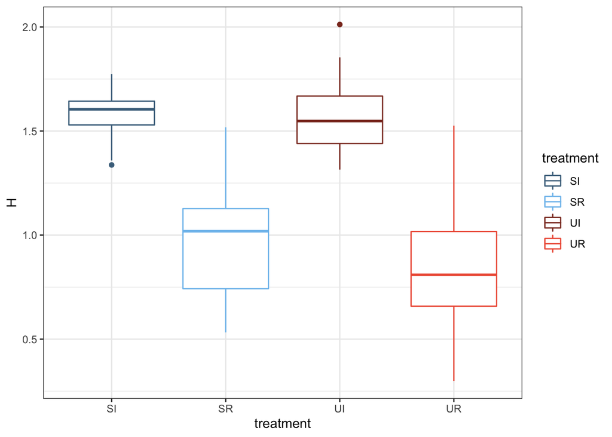

```r
ggplot(diversity.animals.trts, aes(x=treatment, y = H, color = treatment)) + geom_boxplot() + scale_color_manual(values = c("skyblue4","skyblue2", "tomato4", "tomato2")) +  theme(axis.title = element_text(size = 14), axis.text = element_text(size = 12), legend.text = element_text(size = 12), legend.title = element_text(size = 14)) + theme_bw()
```

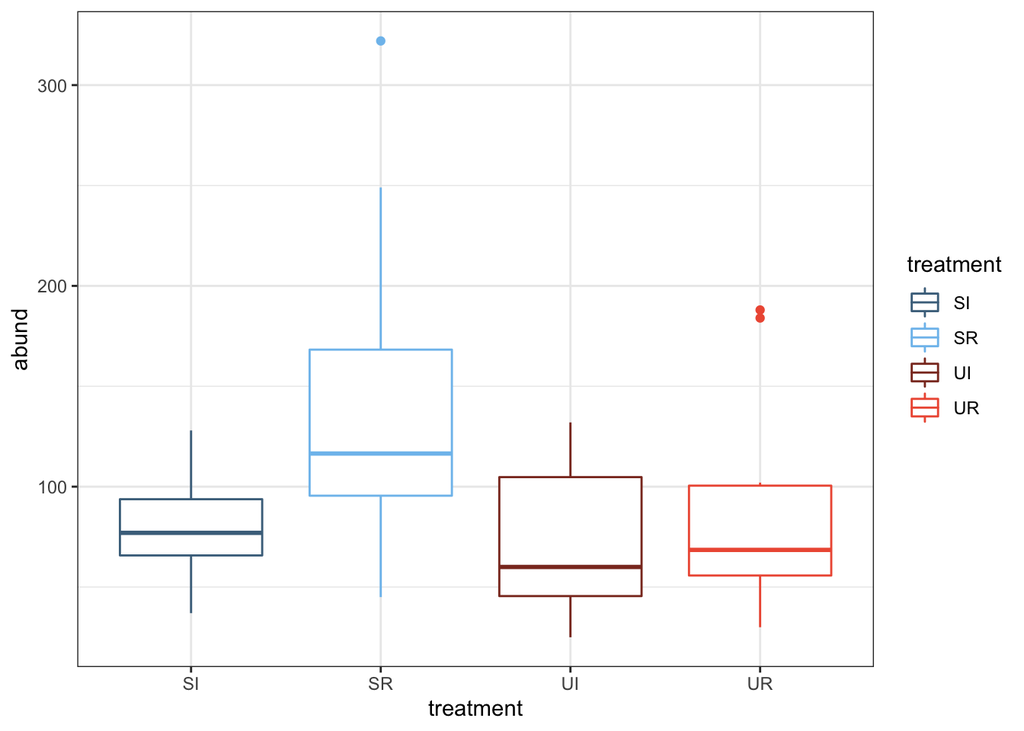

```r
ggplot(diversity.animals.trts, aes(x=treatment, y = abund, color = treatment)) + geom_boxplot() + scale_color_manual(values = c("skyblue4","skyblue2", "tomato4", "tomato2")) +  theme(axis.title = element_text(size = 14), axis.text = element_text(size = 12), legend.text = element_text(size = 12), legend.title = element_text(size = 14)) + theme_bw()
```

This trend is driven by barnacle recruitment, which was REALLY high in shaded removal plots. Might be worth digging into further??

```r
richness <- lm(richness ~ treatment, data = richness.all.trts)
summary(richness)
```

```
##
## Call:
## lm(formula = richness ~ treatment, data = richness.all.trts)
##
## Residuals:
##    Min     1Q Median     3Q    Max
## -4.000 -1.250 -0.125  1.083  6.000
##
## Coefficients:
##             Estimate Std. Error t value Pr(>|t|)
## (Intercept)  11.2500     0.6199  18.147  < 2e-16 ***
## treatmentSR  -0.2500     0.8767  -0.285 0.776862
## treatmentUI  -0.2500     0.8767  -0.285 0.776862
## treatmentUR  -3.5833     0.8767  -4.087 0.000182 ***
## ---
## Signif. codes:  0 '***' 0.001 '**' 0.01 '*' 0.05 '.' 0.1 ' ' 1
##
## Residual standard error: 2.147 on 44 degrees of freedom
## Multiple R-squared:  0.3422, Adjusted R-squared:  0.2974
## F-statistic:  7.63 on 3 and 44 DF,  p-value: 0.000326
```

```r
Anova(richness)
```

```
## Anova Table (Type II tests)
##
## Response: richness
##           Sum Sq Df F value   Pr(>F)
## treatment 105.56  3    7.63 0.000326 ***
## Residuals 202.92 44
## ---
## Signif. codes:  0 '***' 0.001 '**' 0.01 '*' 0.05 '.' 0.1 ' ' 1
```

```r
animal.diversity <- lm(H ~ treatment, data = diversity.animals.trts)
summary(animal.diversity)
```

```
##
## Call:
## lm(formula = H ~ treatment, data = diversity.animals.trts)
##
## Residuals:
##      Min       1Q   Median       3Q      Max
## -0.52955 -0.19417  0.00841  0.13055  0.69720
##
## Coefficients:
##              Estimate Std. Error t value Pr(>|t|)
## (Intercept)  1.581064   0.076784  20.591  < 2e-16 ***
## treatmentSR -0.597049   0.108589  -5.498 1.83e-06 ***
## treatmentUI -0.005067   0.108589  -0.047    0.963
## treatmentUR -0.752378   0.108589  -6.929 1.45e-08 ***
## ---
## Signif. codes:  0 '***' 0.001 '**' 0.01 '*' 0.05 '.' 0.1 ' ' 1
##
## Residual standard error: 0.266 on 44 degrees of freedom
## Multiple R-squared:  0.6414, Adjusted R-squared:  0.6169
## F-statistic: 26.23 on 3 and 44 DF,  p-value: 6.956e-10
```

```r
Anova(animal.diversity)
```

```
## Anova Table (Type II tests)
##
## Response: H
##           Sum Sq Df F value    Pr(>F)
## treatment 5.5668  3  26.228 6.956e-10 ***
## Residuals 3.1130 44
## ---
## Signif. codes:  0 '***' 0.001 '**' 0.01 '*' 0.05 '.' 0.1 ' ' 1
```

```r
animal.abundance <- lm(abund ~ treatment, data = diversity.animals.trts)
summary(animal.abundance)
```

```
##
## Call:
## lm(formula = abund ~ treatment, data = diversity.animals.trts)
##
## Residuals:
##    Min     1Q Median     3Q    Max
## -98.67 -30.50 -11.08  16.29 178.33
##
## Coefficients:
##             Estimate Std. Error t value Pr(>|t|)
## (Intercept)   79.583     15.205   5.234 4.44e-06 ***
## treatmentSR   64.083     21.503   2.980  0.00468 **
## treatmentUI   -8.500     21.503  -0.395  0.69454
## treatmentUR    8.167     21.503   0.380  0.70593
## ---
## Signif. codes:  0 '***' 0.001 '**' 0.01 '*' 0.05 '.' 0.1 ' ' 1
##
## Residual standard error: 52.67 on 44 degrees of freedom
## Multiple R-squared:  0.241,  Adjusted R-squared:  0.1892
## F-statistic: 4.656 on 3 and 44 DF,  p-value: 0.006527
```

```r
Anova(animal.abundance)
```

```
## Anova Table (Type II tests)
##
## Response: abund
##           Sum Sq Df F value   Pr(>F)
## treatment  38755  3  4.6565 0.006527 **
## Residuals 122069 44
## ---
## Signif. codes:  0 '***' 0.001 '**' 0.01 '*' 0.05 '.' 0.1 ' ' 1
```

## 3: Algal diversity & cover

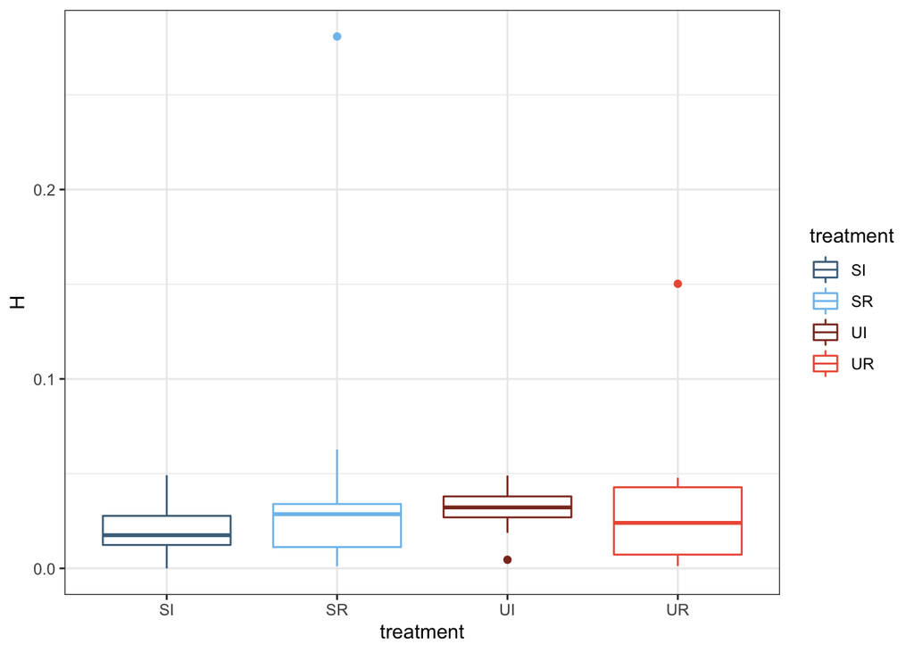

```r
ggplot(diversity.algae.trts, aes(x=treatment, y = H, color = treatment)) + geom_boxplot() + scale_color_manual(values = c("skyblue4","skyblue2", "tomato4", "tomato2")) +  theme(axis.title = element_text(size = 14), axis.text = element_text(size = 12), legend.text = element_text(size = 12), legend.title = element_text(size = 14)) + theme_bw()
```

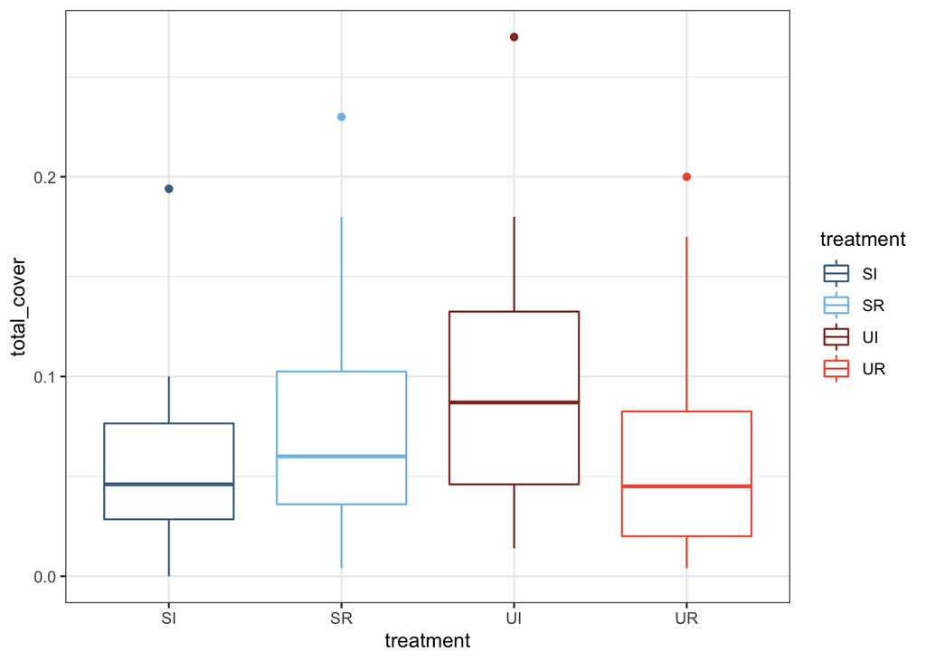

```r
ggplot(diversity.algae.trts, aes(x=treatment, y = total_cover, color = treatment)) + geom_boxplot() + scale_color_manual(values = c("skyblue4","skyblue2", "tomato4", "tomato2")) +  theme(axis.title = element_text(size = 14), axis.text = element_text(size = 12), legend.text = element_text(size = 12), legend.title = element_text(size = 14)) + theme_bw()
```

```r
algal.diversity <- lm(H ~ treatment, data = diversity.algae.trts)
summary(algal.diversity)
```

```
##
## Call:
## lm(formula = H ~ treatment, data = diversity.algae.trts)
##
## Residuals:
##       Min        1Q    Median        3Q       Max
## -0.044040 -0.018388 -0.006687  0.007550  0.235633
##
## Coefficients:
##             Estimate Std. Error t value Pr(>|t|)
## (Intercept)  0.02017    0.01274   1.583    0.121
## treatmentSR  0.02497    0.01802   1.386    0.173
## treatmentUI  0.01082    0.01802   0.601    0.551
## treatmentUR  0.01316    0.01802   0.730    0.469
##
## Residual standard error: 0.04413 on 44 degrees of freedom
## Multiple R-squared:  0.0422, Adjusted R-squared:  -0.02311
## F-statistic: 0.6462 on 3 and 44 DF,  p-value: 0.5895
```

```r
Anova(algal.diversity)
```

```
## Anova Table (Type II tests)
##
## Response: H
##             Sum Sq Df F value Pr(>F)
## treatment 0.003776  3  0.6462 0.5895
## Residuals 0.085700 44
```

```r
algal.cover <- lm(total_cover ~ treatment, data = diversity.algae.trts)
summary(algal.cover)
```

```
##
## Call:
## lm(formula = total_cover ~ treatment, data = diversity.algae.trts)
##
## Residuals:
##      Min       1Q   Median       3Q      Max
## -0.08733 -0.04063 -0.01717  0.02025  0.16867
##
## Coefficients:
##             Estimate Std. Error t value Pr(>|t|)
## (Intercept)  0.05900    0.01894   3.116  0.00323 **
## treatmentSR  0.02033    0.02678   0.759  0.45174
## treatmentUI  0.04233    0.02678   1.581  0.12109
## treatmentUR  0.00550    0.02678   0.205  0.83822
## ---
## Signif. codes:  0 '***' 0.001 '**' 0.01 '*' 0.05 '.' 0.1 ' ' 1
##
## Residual standard error: 0.0656 on 44 degrees of freedom
## Multiple R-squared:  0.06374,    Adjusted R-squared:  -9.546e-05
## F-statistic: 0.9985 on 3 and 44 DF,  p-value: 0.4025
```

```r
Anova(algal.cover)
```

```
## Anova Table (Type II tests)
##
## Response: total_cover
##            Sum Sq Df F value Pr(>F)
## treatment 0.01289  3  0.9985 0.4025
## Residuals 0.18933 44
```

Moral of the story: The animal component of the community seems way more affected than the algal component.

## Visual surveys NMDS

```r
comm.visual <- visuals %>% select(-plot_number)
comm.visual.matrix <- as.matrix(comm.visual)

comm.visual.shade <- metaMDS(comm.visual.matrix, k = 2, try = 400)

treatments.codes <- as.data.frame(plot.info$treatment_original_numeric) %>% rename(treatment_number = 1) %>% mutate(treatment_code = case_when(treatment_number == 1 ~ "UI", treatment_number == 2 ~ "SI", treatment_number == 3 ~ "UR", treatment_number == 4 ~ "SR"))
```

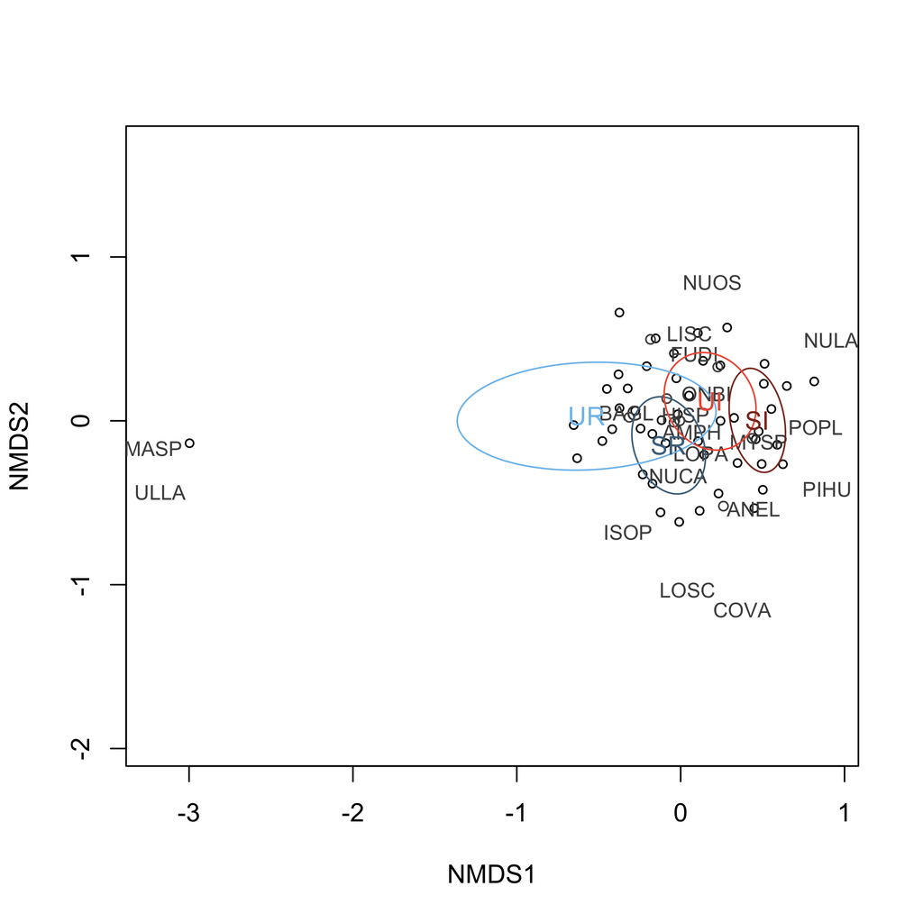

```r
knitr::include_graphics("../outputs/community_visual_shade.png")
```

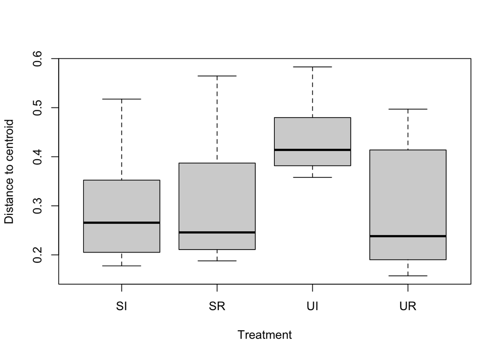

```r
perm.y1 <- adonis(comm.visual.matrix ~ treatment_code, data = treatments.codes, perm = 99)
perm.y1

dist.y1 <- vegdist(comm.visual.matrix, method = "bray")

disp.y1 <- betadisper(dist.y1, type = "centroid", group = treatments.codes$treatment_code)
anova(disp.y1)

boxplot(disp.y1, xlab = "Treatment")
```

[output not shown]